# Cross-Cultural Quantitative Research: Trust and Leadership

Monika Bagociute

September 18, 2026

## Research overview

This study examines how different approaches to vaccine allocation relate to trust in political leadership across participants from four English-speaking countries.

The analysis demonstrates an end-to-end quantitative research workflow, including data preparation, quality screening, survey-based measurement, statistical modelling, effect estimation, exploratory analysis, and sensitivity analysis.

### Research question

Does the framing of vaccine allocation influence reported trust in political leadership, and does this relationship vary across participant characteristics and countries?

### Analytical approach

The primary analysis estimates the relationship between experimental condition and trust while accounting for relevant participant characteristics and country-level variation. Exploratory analyses investigate whether the relationship differs across countries and participant characteristics.

### Tools

- R
- R Markdown
- Linear and mixed-effects modelling
- Estimated marginal means
- Confidence intervals
- Effect sizes
- Data visualisation

## 1. Reproducible Analysis Setup

```r
library(dplyr)
library(tidyr)
library(kableExtra)
```

```r
library(ggplot2)
library(lme4)
library(lmerTest)
library(emmeans)
library(summarytools)
library(rstatix)
library(effectsize)
library(coin)
```

```r
set.seed(828)
```

#### Plot Setup

```r
theme_set(theme_classic(base_size = 12) +
          theme(axis.title = element_text(size = 15, face='bold'),
                axis.title.x = element_text(margin = margin(6, 0, 0, 0)),
                axis.title.y = element_text(margin = margin(0, 6, 0, 0)),
                axis.ticks.y = element_line(color='#4d4d4e'),
                axis.ticks.x = element_blank(),
                strip.background = element_blank()))
```

## Data Preparation

```r
# data_raw <- read.csv("S1 - Data.csv")

data_raw <- read.csv(
  file.path("..", "Data", "raw", "study1_data.csv")
)
```

N = 2044

### Recode variables

```r
data_raw %>%

  mutate(vnat_b = gsub(".*ensure that there are enough vaccines for people.*", "Keep",
                       gsub(".*ensure that people in developing countries have access to vaccines.*",
                            "Distribute", vnat_b)),

         gender_rec = if_else(gender %in% c("Woman", "Man"), gender, "Other"),
         gender_rec = factor(gender_rec, levels = c("Woman", "Man", "Other")),

         race_rec = gsub("Australian", "White", race),
         race_rec = if_else(race_rec == "White", "White", "Other"),
         race_rec = factor(race_rec, levels = c("White", "Other")),

         country = factor(country, levels = c("United States", "Australia",
                                               "Canada", "United Kingdom")),

         edu_rec = recode(education, "Some elementary school / primary school" = "1",
                             "Completed elementary school / primary school" = "2",
                             "Some high school / secondary school" = "3",
                             "Completed high school / secondary school" = "4",
                             "Some college / undergraduate degree" = "5",
                             "Completed college / undergraduate degree" = "6",
                             "Some advanced postgraduate degree" = "7",
                             "Completed advanced postgraduate degree " = "8",
                             "Completed advanced postgraduate degree" = "8"),
         edu_rec = as.numeric(edu_rec),

         cond = factor(cond, c("Redistribution", "Nationalism"))) -> data_raw
```

#### Create Composite measure of trust

```r
data_raw$trust_avg <- (data_raw$trust_1+data_raw$trust_2)/2
```

#### Apply effect coding to experimental condition

```r
data_raw$cond_rec <- recode(data_raw$cond, "Nationalism" = -0.5, "Redistribution" = 0.5)
```

## 3. Data Quality and Exclusions

```r
data_raw %>%
  mutate(failed_att1 = att_check1 != "TikTok",
         failed_att2 = att_check2 != "Roses can suffer with pests like aphids and blackfly",
         failed_comp = comp_check != "How much I trusted the mayor") -> data

data %>%
  select(sub_n, trust_1, trust_2, gender, age, race,
         country, education, ses2, politics, religious) %>%
  mutate(n_missed_key = rowSums(is.na(.)),
         missed_half = n_missed_key > 10/2) %>%
  select(sub_n, n_missed_key, missed_half) %>%
  right_join(data, by='sub_n') -> data
```

Removing:

- 46 participated more than once

```r
data <- filter(data, duplicate_IP == 0, duplicate_ID == 0)
```

- 245 failed 1+ attention check

```r
data <- filter(data, failed_att1 == 0, failed_att2 == 0)
```

- 2 in different country

```r
data <- filter(data, survey_c == country)
```

- 0 responded to less than half of key questions

```r
data <- filter(data, missed_half == 0)
```

- 101 failed comprehension check

```r
data <- filter(data, failed_comp == 0)
```

Post-exclusions N = 1650

| country | n |
| --- | --- |
| United States | 437 |
| Australia | 376 |
| Canada | 437 |
| United Kingdom | 400 |

## 4. Sample Characteristics

N women: 868

Mean age: 41.62

Center covariates

```r
data$politics_raw <- data$politics
data$support_raw <- data$support
data <- mutate_at(data, c("age", "edu_rec", "ses2", "politics",
           "religious", "support"), ~scale(.x, center = TRUE, scale=FALSE))

saveRDS(
  data,
  "../Data/processed/cleaned_data_s1.rds"
)
```

Set contrasts

```r
options(contrasts = c("contr.treatment", "contr.poly"))
```

## 5. Primary Analyses

Country random intercept:

```r
mod <- lmer(trust_avg ~ gender_rec + age + race_rec
          + edu_rec + ses2 + politics + religious
          + support + cond_rec
          + (1|country), data = data)
```

```
## boundary (singular) fit: see help('isSingular')
```

```r
kable(summary(mod)$coefficients)
```

|  | Estimate | Std. Error | df | t value | Pr(>\|t\|) |
| --- | --- | --- | --- | --- | --- |
| (Intercept) | 4.27 | 0.05 | 1638 | 88.86 | 0.00 |
| gender_recMan | -0.07 | 0.06 | 1638 | -1.10 | 0.27 |
| gender_recOther | -0.05 | 0.28 | 1638 | -0.16 | 0.87 |
| age | 0.00 | 0.00 | 1638 | 0.82 | 0.42 |
| race_recOther | 0.03 | 0.07 | 1638 | 0.45 | 0.65 |
| edu_rec | -0.04 | 0.03 | 1638 | -1.70 | 0.09 |
| ses2 | 0.05 | 0.02 | 1638 | 2.26 | 0.02 |
| politics | -0.02 | 0.02 | 1638 | -0.86 | 0.39 |
| religious | 0.03 | 0.02 | 1638 | 1.88 | 0.06 |
| support | -0.06 | 0.02 | 1638 | -2.77 | 0.01 |
| cond_rec | 1.54 | 0.06 | 1638 | 24.70 | 0.00 |

#### Estimate a simplified model without the country random intercept

```r
mod <- lm(trust_avg ~ gender_rec + age + race_rec
          + edu_rec + ses2 + politics + religious
          + support + cond_rec, data = data)
```

```r
kable(summary(mod)$coefficients)
```

|  | Estimate | Std. Error | t value | Pr(>\|t\|) |
| --- | --- | --- | --- | --- |
| (Intercept) | 4.27 | 0.05 | 88.86 | 0.00 |
| gender_recMan | -0.07 | 0.06 | -1.10 | 0.27 |
| gender_recOther | -0.05 | 0.28 | -0.16 | 0.87 |
| age | 0.00 | 0.00 | 0.82 | 0.42 |
| race_recOther | 0.03 | 0.07 | 0.45 | 0.65 |
| edu_rec | -0.04 | 0.03 | -1.70 | 0.09 |
| ses2 | 0.05 | 0.02 | 2.26 | 0.02 |
| politics | -0.02 | 0.02 | -0.86 | 0.39 |
| religious | 0.03 | 0.02 | 1.88 | 0.06 |
| support | -0.06 | 0.02 | -2.77 | 0.01 |
| cond_rec | 1.54 | 0.06 | 24.70 | 0.00 |

```r
kable(confint(mod, "cond_rec", level = 0.95))
```

|  | 2.5 % | 97.5 % |
| --- | --- | --- |
| cond_rec | 1.42 | 1.66 |

```r
kable(emmeans(mod, specs = "cond_rec"))
```

| cond_rec | emmean | SE | df | lower.CL | upper.CL |
| --- | --- | --- | --- | --- | --- |
| -0.5 | 3.48 | 0.1 | 1638 | 3.28 | 3.68 |
| 0.5 | 5.02 | 0.1 | 1638 | 4.82 | 5.21 |

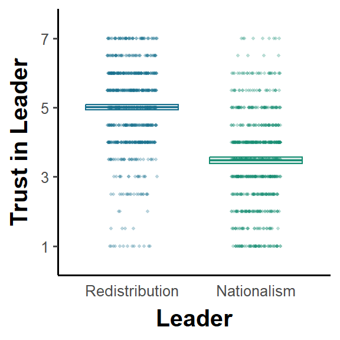

```r
data %>%
  group_by(cond) %>%
  summarise(mean = mean(trust_avg), sd = sd(trust_avg),
            count = n(), se = sd / sqrt(count),
            ci = se * qt(1-(0.05/2), count-1))  %>%
  mutate(xpos = row_number()) %>%
  ggplot(aes(x=cond, y = mean, color=cond, fill=cond)) +
  geom_jitter(data = data, aes(y = trust_avg), width = .2,
              height = 0, alpha = .3, size = 0.75, shape = 16) +
  geom_crossbar(aes(ymin = mean-ci, ymax = mean+ci),
                alpha = .2, linewidth = 0.4, fatten = 1.75, width = .75) +
  scale_fill_manual(values = c("#176f8d", "#158d71")) +
  scale_color_manual(values = c("#176f8d", "#158d71")) +
  xlab('Leader') +
  ylab('Trust in Leader') +
  theme(legend.position = "none") +
  scale_y_continuous(breaks=seq(1, 7, 2), limits=c(0.5, 7.5))
```

```r
ggsave("S1 - Fig 1.pdf", width = 2.75, height = 2.45)
```

## 6. Exploratory Analyses

### Effect by country:

```r
mod <- lm(trust_avg ~ cond_rec * country, data = data)
```

```r
kable(summary(mod)$coefficients)
```

|  | Estimate | Std. Error | t value | Pr(>\|t\|) |
| --- | --- | --- | --- | --- |
| (Intercept) | 4.28 | 0.06 | 70.50 | 0.00 |
| cond_rec | 1.50 | 0.12 | 12.37 | 0.00 |
| countryAustralia | -0.12 | 0.09 | -1.33 | 0.18 |
| countryCanada | 0.03 | 0.09 | 0.38 | 0.70 |
| countryUnited Kingdom | -0.05 | 0.09 | -0.54 | 0.59 |
| cond_rec:countryAustralia | 0.19 | 0.18 | 1.08 | 0.28 |
| cond_rec:countryCanada | 0.06 | 0.17 | 0.36 | 0.72 |
| cond_rec:countryUnited Kingdom | -0.10 | 0.18 | -0.56 | 0.57 |

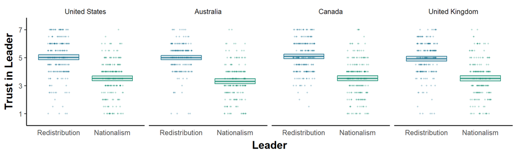

```r
data %>%
  group_by(cond, country) %>%
  summarise(mean = mean(trust_avg), sd = sd(trust_avg),
            count = n(), se = sd / sqrt(count),
            ci = se * qt(1-(0.05/2), count-1))  %>%
  mutate(xpos = row_number()) %>%
  ggplot(aes(x=cond, y = mean, color=cond, fill=cond)) +
  geom_jitter(data = data, aes(y = trust_avg), width = .2,
              height = 0, alpha = .3, size = 0.75, shape = 16) +
  geom_crossbar(aes(ymin = mean-ci, ymax = mean+ci),
                alpha = .2, linewidth = 0.4, fatten = 1.75, width = .75) +
  scale_fill_manual(values = c("#176f8d", "#158d71")) +
  scale_color_manual(values = c("#176f8d", "#158d71")) +
  xlab('Leader') +
  ylab('Trust in Leader') +
  theme(legend.position = "none") +
  scale_y_continuous(breaks=seq(1, 7, 2), limits=c(0.5, 7.5)) +
  facet_wrap(~country, nrow = 1)
```

```r
ggsave("S1 - Fig 2.pdf", width = 8.40, height = 2.64)
```

### Without covariates

```r
mod <- lm(trust_avg ~ cond_rec, data = data)
```

```r
kable(summary(mod)$coefficients)
```

|  | Estimate | Std. Error | t value | Pr(>\|t\|) |
| --- | --- | --- | --- | --- |
| (Intercept) | 4.25 | 0.03 | 136.03 | 0 |
| cond_rec | 1.54 | 0.06 | 24.60 | 0 |

```r
kable(confint(mod, "cond_rec", level = 0.95))
```

|  | 2.5 % | 97.5 % |
| --- | --- | --- |
| cond_rec | 1.41 | 1.66 |

### Participant Politics

Nationalism:

```r
test <- t.test(filter(data, vnat_b == "Keep",
                      cond == "Redistribution")$trust_avg,
               filter(data, vnat_b == "Keep",
                      cond == "Nationalism")$trust_avg)

efsz <- cohens_d(filter(data, vnat_b == "Keep",
                      cond == "Redistribution")$trust_avg,
               filter(data, vnat_b == "Keep",
                      cond == "Nationalism")$trust_avg)
```

t(735) = 6.27, p = 0, d = 0.46, CI = [0.31, 0.6]

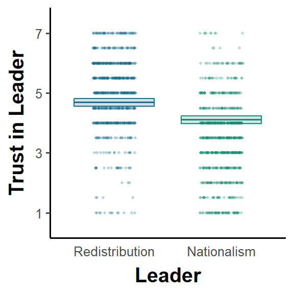

```r
data %>%
  filter(vnat_b == "Keep") %>%
  group_by(cond) %>%
  summarise(mean = mean(trust_avg), sd = sd(trust_avg),
            count = n(), se = sd / sqrt(count),
            ci = se * qt(1-(0.05/2), count-1))  %>%
  mutate(xpos = row_number()) %>%
  ggplot(aes(x=cond, y = mean, color=cond, fill=cond)) +
  geom_jitter(data = data, aes(y = trust_avg), width = .2,
              height = 0, alpha = .3, size = 0.75, shape = 16) +
  geom_crossbar(aes(ymin = mean-ci, ymax = mean+ci),
                alpha = .2, linewidth = 0.4, fatten = 1.75, width = .75) +
  scale_fill_manual(values = c("#176f8d", "#158d71")) +
  scale_color_manual(values = c("#176f8d", "#158d71")) +
  xlab('Leader') +
  ylab('Trust in Leader') +
  theme(legend.position = "none") +
  scale_y_continuous(breaks=seq(1, 7, 2), limits=c(0.5, 7.5))
```

```r
ggsave("S1 - Fig 3.pdf", width = 2.75, height = 2.45)
```

Conservatives:

```r
test <- t.test(filter(data, politics_raw == 7,
                      cond == "Redistribution")$trust_avg,
               filter(data, politics_raw == 7,
                      cond == "Nationalism")$trust_avg)

efsz <- cohens_d(filter(data, politics_raw == 7,
                      cond == "Redistribution")$trust_avg,
               filter(data, politics_raw == 7,
                      cond == "Nationalism")$trust_avg)
```

t(47) = 0.21, p = 0.836, d = 0.06, CI = [-0.5, 0.62]